# Reproducible Research Project 1 - John Hopkins @ Coursera

This is the R Markdown file for the data analisys of Project 1.

### I - We start by loading the libraries and the data needed for this assignment:

```r
library(dplyr)
library(ggplot2)
library(lubridate)

activity_data <- data.table::fread("activity.csv")
```

### II - What is mean total number of steps taken per day?

#### 1 - Calculate the total number of steps taken per day:

```r
total_steps_by_day <- activity_data[,sum(steps, na.rm = FALSE), by=date]
```

Converting column date(character) to date(date):

```r
total_steps_by_day$date <- parse_date_time(total_steps_by_day$date,"ymd", tz="GMT")
names(total_steps_by_day) <- c("date", "totalsteps")
```

#### 2 - If you do not understand the difference between a histogram and a barplot, research the difference between them. Make a histogram of the total number of steps taken each day

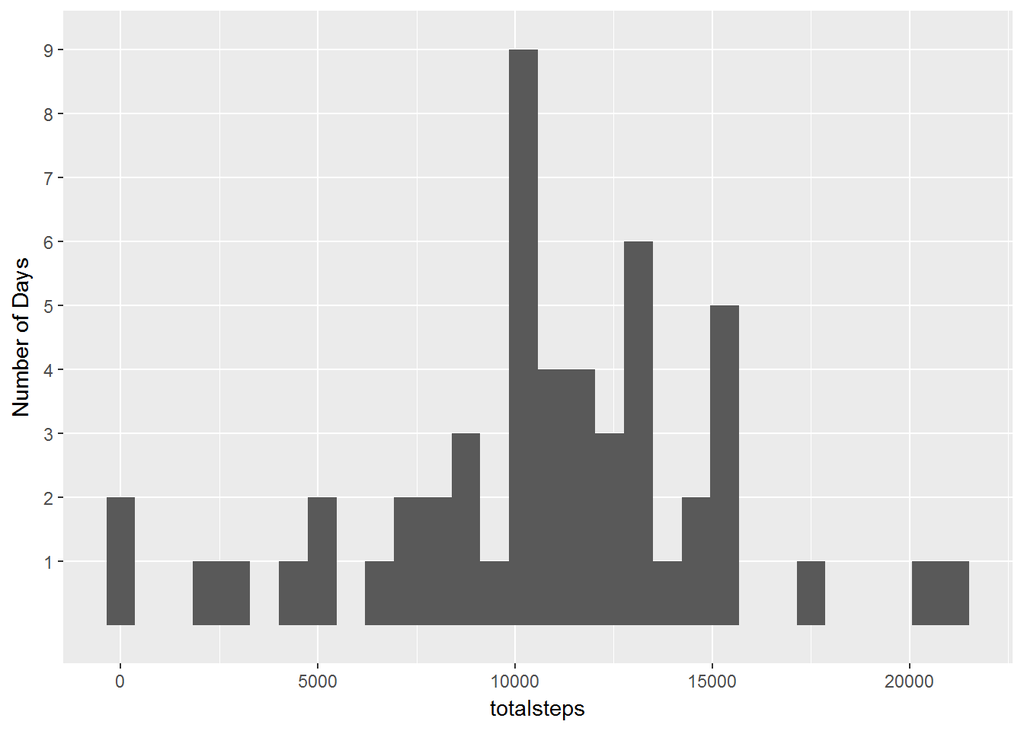

```r
histogram <- ggplot(total_steps_by_day, aes(totalsteps))
histogram + geom_histogram() + scale_y_discrete("Number of Days", limits=as.character(1:9))
```

#### 3 - Calculate and report the mean and median of the total number of steps taken per day

```r
mean(total_steps_by_day$totalsteps, na.rm = TRUE)
```

```
## [1] 10766.19
```

```r
median(total_steps_by_day$totalsteps, na.rm = TRUE)
```

```
## [1] 10765
```

**Answers**: -Mean steps per day: 10766.19 -Median steps per day: 10765

### III - What is the average daily activity pattern?

#### 1 - Make a time series plot (i.e. type = “l”) of the 5-minute interval (x-axis) and the average number of steps taken, averaged across all days (y-axis)

```r
average_steps_by_minutes <- activity_data[,mean(steps,na.rm=TRUE), by=interval]
names(average_steps_by_minutes) <- c("interval", "average.steps")
```

Rounding average steps:

```r
average_steps_by_minutes$average.steps <- round(average_steps_by_minutes$average.steps)
```

Plotting:

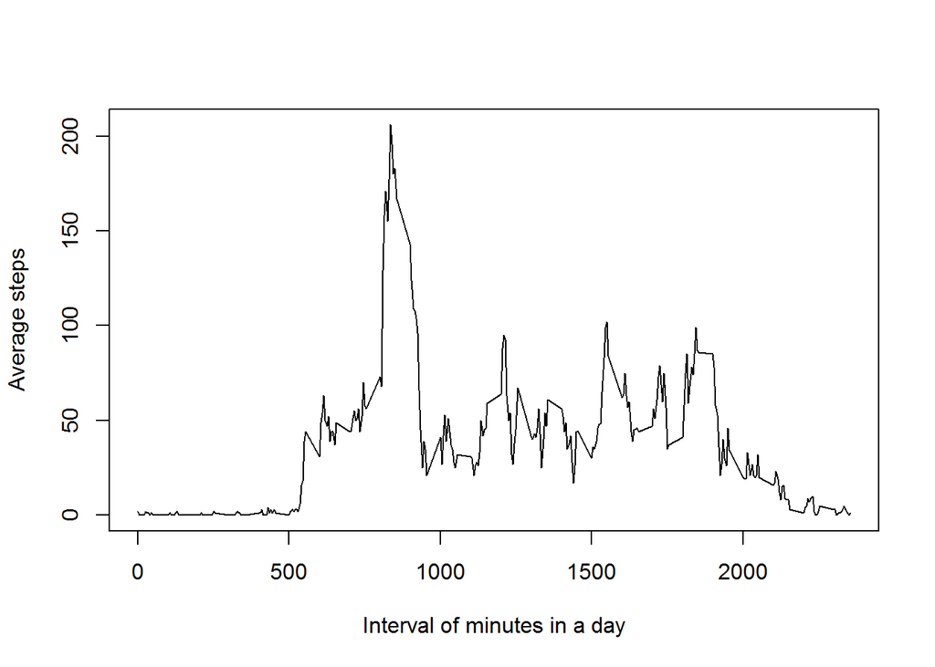

```r
plot(average_steps_by_minutes$interval,average_steps_by_minutes$average.steps, type="l", xlab = "Interval of minutes in a day", ylab = "Average steps")
```

#### 2 - Which 5-minute interval, on average across all the days in the dataset, contains the maximum number of steps?

```r
average_steps_by_minutes$interval[which(average_steps_by_minutes$average.steps==max(average_steps_by_minutes$average.steps))]
```

```
## [1] 835
```

```
Answer: The interval is 835 (graphically, looks ok).
```

### IV - Imputing missing values

```r
sum(is.na(activity_data$steps))
```

```
## [1] 2304
```

Answer: Number of NAs is 2304.

#### 2 - Devise a strategy for filling in all of the missing values in the dataset. The strategy does not need to be sophisticated. For example, you could use the mean/median for that day, or the mean for that 5-minute interval, etc.

Answer: I am going to use mean steps of that 5-minute interval.

```r
mean_steps_per_day <- activity_data[,mean(steps, na.rm = FALSE), by=date]
names(mean_steps_per_day) <- c("date","average.steps")
median_steps_per_day <- activity_data[,median(steps, na.rm = FALSE), by=date]
names(median_steps_per_day) <- c("date","median.steps")
```

#### 3 - Create a new dataset that is equal to the original dataset but with the missing data filled in.

```r
activity_data_NAs_filled <- activity_data # Copies the data frame #
index_of_NAs <- is.na(activity_data$steps) # List of lines where the NAs are #
```

Where there is an NA, it takes the value of that 5-min interval mean from the other DT; If a «step» is NA, it fetches the mean value of the «step» in that «interval»; To know what «interval» is, it uses match() to match «interval» in DT1 (which is “activity_data_NAs_filled”) to the «interval» in DT2 (which is “average_steps_by_minutes”).

```r
activity_data_NAs_filled[index_of_NAs,"steps"] <- average_steps_by_minutes[match(activity_data_NAs_filled[index_of_NAs,interval], average_steps_by_minutes$interval),"average.steps"]
```

```r
total_steps_by_day_NAs_filled <- activity_data_NAs_filled[,sum(steps), by=date]
names(total_steps_by_day_NAs_filled) <- c("date", "totalsteps")
```

Convert the “date” column from char to date:

```r
total_steps_by_day_NAs_filled$date <- parse_date_time(total_steps_by_day$date,"ymd", tz="GMT")
```

Plot:

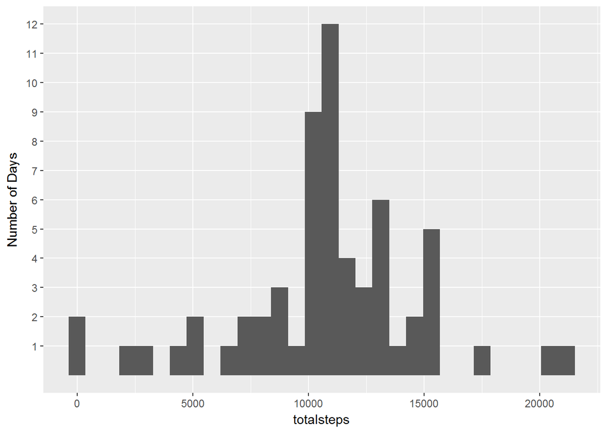

```r
histogram <- ggplot(total_steps_by_day_NAs_filled, aes(totalsteps))
histogram + geom_histogram() + scale_y_discrete("Number of Days", limits=as.character(1:12))
```

```r
mean_steps_per_day_NAs_filled <- activity_data_NAs_filled[,mean(steps), by=date]
names(mean_steps_per_day_NAs_filled) <- c("date","average.steps")
mean_steps_per_day_NAs_filled$date <- parse_date_time(mean_steps_per_day_NAs_filled$date,"ymd", tz="GMT")

median_steps_per_day_NAs_filled <- activity_data_NAs_filled[,median(steps), by=date]
names(median_steps_per_day_NAs_filled) <- c("date","median.steps")
median_steps_per_day_NAs_filled$date <- parse_date_time(median_steps_per_day_NAs_filled$date,"ymd", tz="GMT")
```

### V -Are there differences in activity patterns between weekdays and weekends?

Factor levels:

```r
activity_data_NAs_filled$date <- parse_date_time(activity_data_NAs_filled$date,"ymd", tz="GMT")
mean_steps_per_day_NAs_filled <- mutate(mean_steps_per_day_NAs_filled, type_of_day = ifelse(weekdays(mean_steps_per_day_NAs_filled$date) %in% c("sÃ¡bado", "domingo"), "Weekend", "Weekday"))
median_steps_per_day_NAs_filled <- mutate(median_steps_per_day_NAs_filled, type_of_day = ifelse(weekdays(median_steps_per_day_NAs_filled$date) %in% c("sÃ¡bado", "domingo"), "Weekend", "Weekday"))
```

The names “sÃ¡bado”, “domingo” are the names of “saturday” and “sunday” in my native language (portuguese). Due to my computer being in portuguese, when parsing the weekdays, R gets the names in portuguese.

Time series plot:

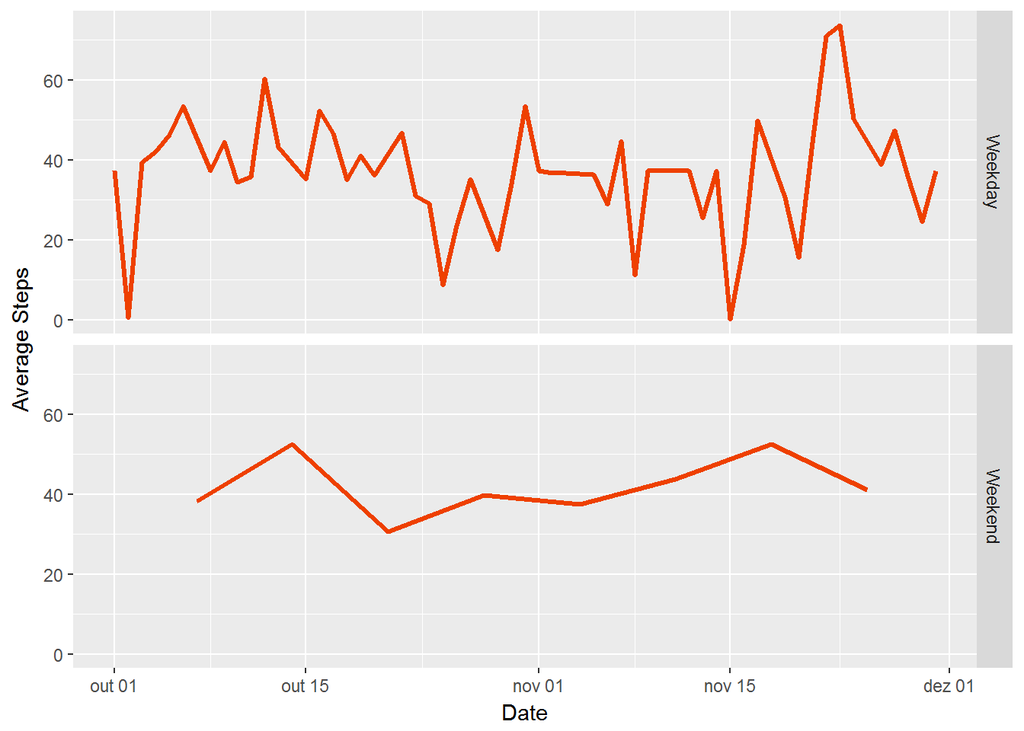

```r
gp <- ggplot(mean_steps_per_day_NAs_filled, aes(date,average.steps))
gp +  geom_line(color="orangered2", size=1.2) + facet_grid(type_of_day~.) + xlab("Date") + ylab("Average Steps")
```